# Analyzing Structure Results with STRUCTURE HARVESTER

# Set-up for STRUCTURE HARVESTER

- The program is an online interface found here: http://taylor0.biology.ucla.edu/structureHarvester/
- Citation: Earl, Dent A. and vonHoldt, Bridgett M. (2012) STRUCTURE HARVESTER: a website and program for visualizing STRUCTURE output and implementing the Evanno method. Conservation Genetics Resources vol. 4 (2) pp. 359-361 doi: 10.1007/s12686-011-9548-7

### STRUCTURE HARVESTER requires you to zip the directory with all of your STRUCTURE results before analyzing:

```bash
#first, navigate to directory that holds your structure results
zip -r StructureResults.zip DirectoryName #need to fill in directory name with your appropriate STRUCTURE directory
```

### Browse for your zipped file and click harvest:

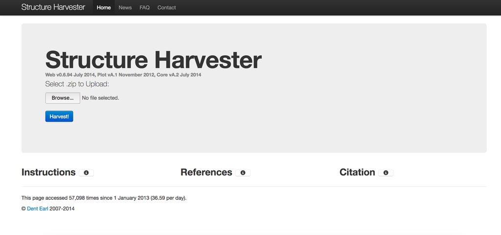

# Results!

**Funk et al. 2016 inferred the best-supported value of K using mean LnP(K) and the delta K method**

- For the delta K method, Funk et al. 2016 found that two groups was most supported in the data. They suggest that is an underestimate based on other results. Our results are in agreement:

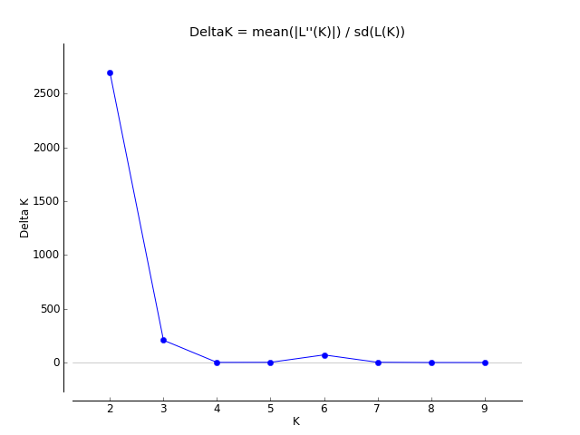

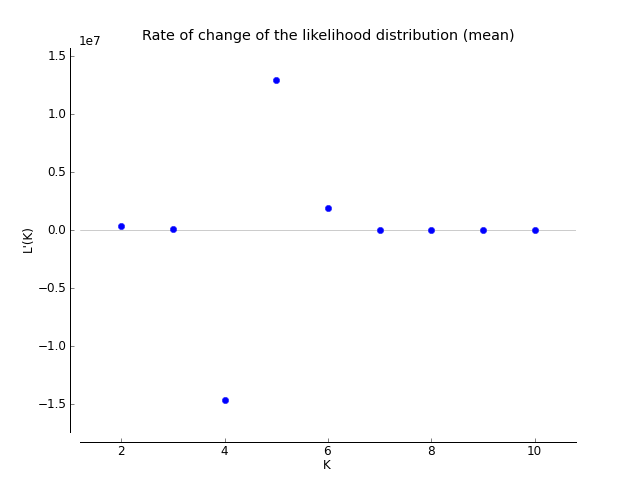